# Statistical Learning Project

Ibrahim Bashir

9/21/2021

### Section 1

Our aim for this section is to create a graph that represents and opens up a possible discussion about the relationship between new_cases of the coronavirus in Israel from our data set with some selection of variables from our demographics data set.

Here we open and read the data from both the data sets.

```r
# The coronavirus cases is already joined with our demographic data set (done independently) and split into train and test data sets
cases_demog <- read_csv("train_cases_demographics.csv",locale=locale(date_names="he",encoding="UTF-8"))
tester <- read_csv("test_features.csv",locale=locale(date_names="he",encoding="UTF-8"))
```

In this section we choose to pick 4 total variables: new_cases, town_east_coord & town_north_coord (coordinates of the towns/localities), and population. We will represent the data in an interactive map using the leaflet package, but to do so we must scale the coordinates of our data set to fit appropriately with the leaflet functions (did this by trial and error).

```r
# Choosing the variables using dplyr's select() function, we also convert the variables into type numeric to be able to graph and manipulate them
isr <- cases_demog %>% dplyr::select(town_east_coord,town_north_coord,new_cases,population) %>% mutate_all(as.numeric)

# Scaling the coordinates
isr$town_east_coord <- isr$town_east_coord/11090+33.19
isr$town_north_coord <- isr$town_north_coord/11090+26.06

# Choosing colors
colorz <- colorRampPalette(c("#ffbf00","#ff0000"))(diff(range(isr$new_cases)))

# Defining the text we will use in our graph using the columns from our dataframe
isr <- isr %>% mutate(town=cases_demog$town_eng.y, town_code=cases_demog$town_code)
mytext <- paste(
   "Town: ", isr$town, "<br/>",
   "Town Code: " , isr$town_code, "<br/>",
   "Population: ", isr$population, "<br/>",
   "New Cases: ", isr$new_cases, sep="") %>%
  lapply(htmltools::HTML)

# Initiating the map using leaflet and adjusting it according to the appropriate parameters. We also choose to set markers for each of the bubbles with our previously defined text, and finally a legend for the severity of the new_cases.
leaflet(isr) %>% addTiles() %>% setView(lat=31.4, lng=35.203072, zoom=7.3) %>% addProviderTiles("Esri.WorldGrayCanvas") %>%
  addCircleMarkers(~town_east_coord, ~town_north_coord, fillColor=~colorz,label=mytext,
                   fillOpacity=1, color="white", radius=~population/5000, stroke=FALSE,
                   labelOptions=labelOptions(style=list("font-weight"="normal",padding="3px 8px"),
                                             textsize="13px",direction="auto")) %>%
  addLegend(pal=colorNumeric(colorz, isr$new_cases),values=seq(length(colorz)),opacity=0.9, title="New Cases", position = "bottomright" )
```

[interactive chart not shown]

Our final output is an interactive bubble map of the new cases in Israel (zoom-able too). The data that is used are the coordinates, the names of the towns, the town codes, their populations, and new cases. We have a legend to show the range of the colors, and the side of the points are determined by the size of the populations of the towns. Hovering over a point gives you all of the information. We can see that the cases hit certain areas more than others, as expected since the more populated areas and developed cities will have more movement. One interesting thing worth noting though is how the towns up north which have decently sized populations were not too infected. This suggests that the northern (and southern) towns probably had less in-and-out movement/travelers compared to the more central tows.

### Section 2

```r
# Making a function for fitting a Ridge regression on data as input according to a lambda parameter
ridge <- function(train, lambda, s=F){
  X <- if(s) scale(train[,2:dim(train)[2]]) else train[,2:dim(train)[2]]
  solve(t(X)%*%X+lambda*diag(dim(X)[2]))%*%t(X)%*%as.vector(train[,1])
}
```

##### b) Building Ridge Regression Model

```r
# Function to replace missing values with the mean/median of the column
missing_vals <- function(column){
  ifelse(is.na(column),median(column,na.rm=T),column)
}

# Function to organize and convert the data into operable types, then clean and split the data into a train and validation data sets
splitter <- function(data){
  # Preparing Data, taking out unnecessary variables, calculating our response variable etc
  data <- data %>% drop_na() %>%
    mutate(y = new_cases/population) %>% # Defining our response var and leaving unwanted dependent vars
    dplyr::select(-c(new_cases,population,agas_code,mahoz,town_eng.y,
                     `...1`,town_code,town_north_coord,town_east_coord)) %>%
    dplyr::select(y, everything())
  splits <- initial_split(data,prop=0.7,strata="town") # Another: data%>%group_by(town)%>%sample_frac(0.7)
  trained <- training(splits) %>% dplyr::select(-town) %>% mutate_all(as.numeric) %>% drop_na()
  tested <- testing(splits) %>% dplyr::select(-town) %>% mutate_all(as.numeric) %>% drop_na()

  list('train'=trained,'validation'=tested)
}
```

To split the training data set into train + validation data sets, using my previous analysis from section 1, I wanted to keep in mind to sample towns from throughout its distribution. If I randomly sampled/split the data, since the more populated areas have the same town names and town-statistics, I wanted to ensure that I had sampled from every town/region. This is called stratified sampling, and in our case, with respect to the towns. I also disregarded the string variables and agas + town codes, and decided to keep all the other numerical variables to further in my analysis. I also took out NA values, which may make way for almost negligible bias, but it turned out that when I calculated the MSE, it was better this way than to replace the values with their means/medians. This is probably because this data set is large, however I will do it for the final testing data set in Question 3 because it is smaller so it won’t affect as much and may prevent bias.

```r
ridge_data <- splitter(cases_demog) # Cleaning and splitting data according to our previously defined func.
x_valid <- ridge_data$validation %>% dplyr::select(-y) # The x and y of the validation data sets
y_valid <- ridge_data$validation %>% dplyr::select(y)
trained <- ridge_data$train

lambdas <- round(10^seq(10, -3, length=100),3) # The lambdas we will use
MSEs <- data.frame(MSE=as.numeric(),Lambda=as.numeric(),SD=as.numeric()) # Dataframe to store our data
y_preds <- data.frame(seq(length(y_valid$y)))
betas <- data.frame(seq(dim(trained)[2]-1))

# A loop to iterate through all the lambdas and fit a ridge regression model of the data according to them.
for(l in lambdas){
  beta_l <- ridge(as.matrix(trained),l)
  betas <- cbind(betas, beta_l)

  y_pred <- as.matrix(x_valid)%*%beta_l
  y_preds <- cbind(y_preds, y_pred)

  MSE <- colMeans((y_valid-y_pred)^2)
  MSEs <- rbind(MSEs, cbind('MSE'=MSE,'Lambda'=l))
}
colnames(y_preds) <- c('index',lambdas)
colnames(betas) <- c('index',lambdas)

# The optimal model chosen as the one with the minimum MSE (mean squared error)
mins <- MSEs[which(MSEs$MSE==min(MSEs$MSE)),]
mins
```

```
##              MSE Lambda
## y71 3.800741e-05  4.751
```

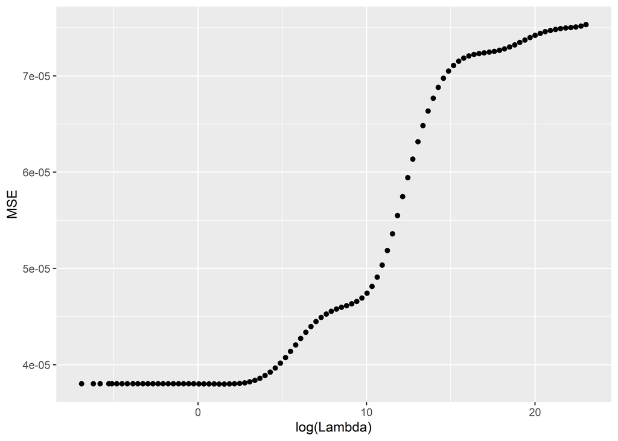

```r
# Plot the MSE as a function of log(lambda)
ggplot(data=MSEs, aes(log(Lambda),MSE)) + geom_point()
```

The plot above illustrates the MSE (minimum square error) of each model as a function of log(lambda). We can choose the model and lambda according to the minimum MSE.

Here we will show the aforermentioned optimal model (the coeffs according to the chosen lambda value).

```r
y_optimal <- y_preds %>% dplyr::select(paste(mins$Lambda))
beta_optimal <- betas %>% dplyr::select(paste(mins$Lambda))
round(beta_optimal,8)
```

```
##                                          4.751
## accumulated_vaccination_first_dose  0.00000733
## town_pop_denisty                    0.00000000
## town_diabetes_rate                 -0.00001440
## town_perc_clalit                   -0.00004846
## town_income                         0.00000239
## town_bagrut                        -0.00011459
## town_socioeconomic_index           -0.00704723
## agas_socioeconomic_index           -0.00391984
## pop_over20                         -0.00000183
## pop_over50                          0.00000091
## pop_over70                         -0.00000772
```

I used the formulas defined from the mathematical definition of Ridge regression to not only calculate the Ridge regression, but also to predict the y response through the validation data set. I did this for multiple values of lambda ranging from 0.001 - 10^10 (split by 100 numbers). After doing so, I calculated the MSE for each and identified the model and predictions with the lowest score.

##### 2c) Residual Plot of Our Model

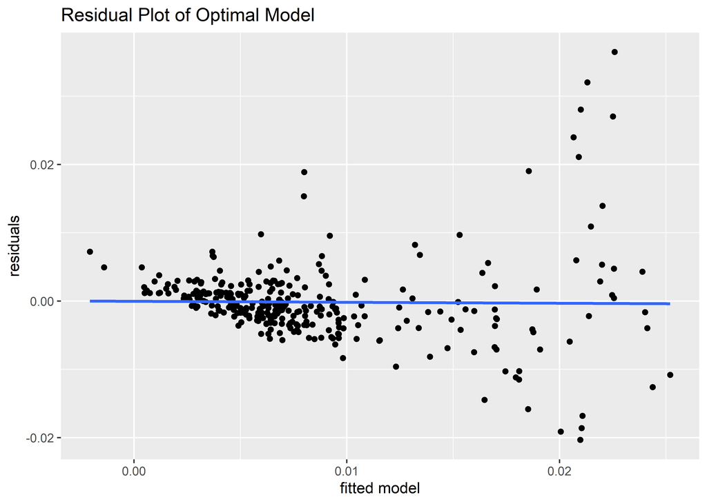

```r
# Manually estimate residuals and store it in a dataframe with the predictions
resids <- as.data.frame(y_valid - y_optimal) %>% cbind(y_optimal)
colnames(resids) <- c('residuals','fitted model')

# Plot the residuals
ggplot(resids,aes(`fitted model`,residuals)) + geom_point() + geom_smooth(method="lm",se=FALSE) + labs(title="Residual Plot of Optimal Model")
```

As expected, the abline of the residual plot resides on the 0, since their expectation is 0. Seeing as how many of the points on the left-half of the graph are close to the origin, but have the right-half more dispersed, this signifies some heteroscedasticity. This signifies that there are varying/differing variances among the features/explanatory variables.

### Section 3

In this section we will will fit models using cross-validation in accordance to the ‘glmnet’ package to estimate optimal parameters for lambda and alpha (so not necessarily ridge, but perhaps Lasso or ElasticNet).

Here we split our data as we have done previously, implement our cross-validation and represent the results of the MSE of each model (for different alphas) as a function of log(lambda) in a plot.

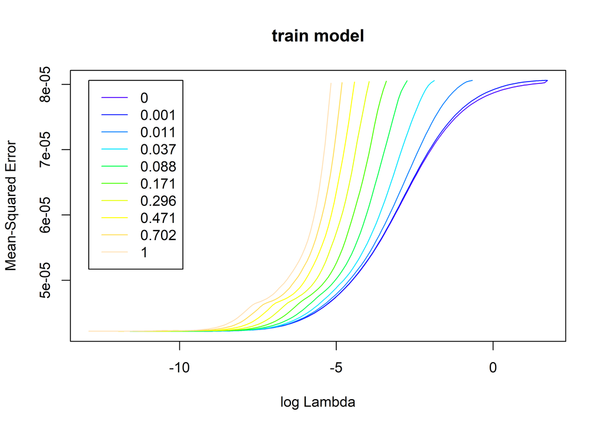

```r
# Setting up the model for the whole train data set
trainers <- cases_demog %>% na_if("..") %>%
  dplyr::select(-c(agas_code,mahoz,town_eng.y,`...1`,town_code,town,town_north_coord,town_east_coord)) %>%
  mutate_all(as.numeric) %>% mutate(y = new_cases/population) %>% dplyr::select(-c(new_cases,population))

# We put in the mean/median for the NA values in the train data set
trainers <- trainers %>% mutate(town_pop_denisty = missing_vals(town_pop_denisty),
                                town_diabetes_rate = missing_vals(town_diabetes_rate),
                                agas_socioeconomic_index = missing_vals(agas_socioeconomic_index))

# Remove all the irrelevant variables from the testing data set
testers <- tester %>% na_if("..") %>%
  dplyr::select(-c(population,agas_code,mahoz,town_eng.y,`...1`,town_code,town,town_north_coord,town_east_coord)) %>% mutate_all(as.numeric)

# We put in the mean/median for the NA values in the test data set
testers <- testers %>% mutate(town_pop_denisty = missing_vals(town_pop_denisty),
                              town_diabetes_rate = missing_vals(town_diabetes_rate),
                              agas_socioeconomic_index = missing_vals(agas_socioeconomic_index))

# Cross validation of alphas and lambdas for training data, display results as MSE vs the log(lambda) in a plot for different alphas
a <- round(seq(0,1,len=10)^3,3)
fit.cva <- cva.glmnet(y~.,data=trainers, alpha=a)
plot(fit.cva, main='train model')
```

Let us create a table displaying all the parameters of the model(s) arranged by the best MSE value.

```r
# Now let us find all the optimal parameters which minimize the MSE
MSEs <- unlist(foreach(z=fit.cva$modlist) %do% min(z$cvm)) # min(unlist(yay)) if we want min
lambda.mins <- unlist(foreach(z=fit.cva$modlist) %do% min(z$lambda.min))
lambda.1ses <- unlist(foreach(z=fit.cva$modlist) %do% min(z$lambda.1se))
SE.mins <- unlist(foreach(z=fit.cva$modlist) %do% min(z$cvsd[z$lambda==z$lambda.min]))
SE.1ses <- unlist(foreach(z=fit.cva$modlist) %do% min(z$cvsd[z$lambda==z$lambda.1se]))

# Display all the results in a table
estimates <- as.data.frame(cbind(a,MSEs,lambda.mins,lambda.1ses,SE.mins,SE.1ses))
kbl(estimates %>% arrange(MSEs)) %>% kable_paper() %>% scroll_box(width = "100%", height = "200px")
```

| a | MSEs | lambda.mins | lambda.1ses | SE.mins | SE.1ses |
| --- | --- | --- | --- | --- | --- |
| 0.011 | 4.22e-05 | 0.0000515 | 0.0053947 | 4.8e-06 | 5.9e-06 |
| 0.037 | 4.22e-05 | 0.0000388 | 0.0044627 | 4.8e-06 | 5.9e-06 |
| 0.088 | 4.22e-05 | 0.0000285 | 0.0032790 | 4.8e-06 | 5.9e-06 |
| 0.171 | 4.22e-05 | 0.0000194 | 0.0022307 | 4.8e-06 | 5.8e-06 |
| 0.296 | 4.22e-05 | 0.0000070 | 0.0015522 | 4.8e-06 | 5.7e-06 |
| 0.471 | 4.22e-05 | 0.0000049 | 0.0011750 | 4.8e-06 | 5.7e-06 |
| 0.702 | 4.22e-05 | 0.0000039 | 0.0008652 | 4.8e-06 | 5.6e-06 |
| 1.000 | 4.22e-05 | 0.0000025 | 0.0006666 | 4.8e-06 | 5.6e-06 |
| 0.001 | 4.25e-05 | 0.0005664 | 0.0063630 | 5.0e-06 | 6.0e-06 |
| 0.000 | 4.25e-05 | 0.0005664 | 0.0063630 | 5.0e-06 | 6.0e-06 |

The MSE of the optimal model (optimal alpha) as a function of log(lambda) with error bars.

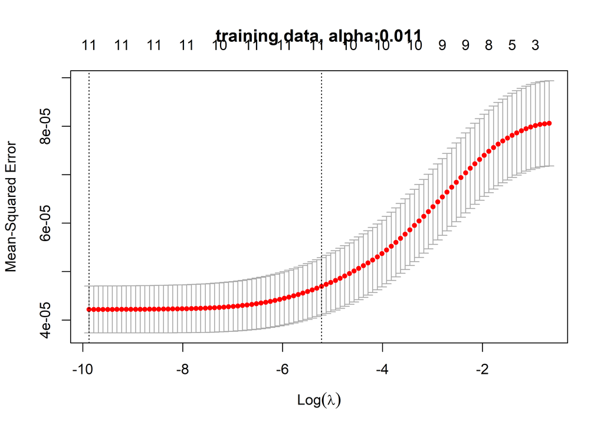

```r
# Now let us find the optimal parameters which minimize the MSE and display the MSE vs log(lambda) with the standard error in a plot
params1 <- estimates %>% dplyr::filter(MSEs == min(estimates$MSEs))
plot(fit.cva$modlist[[which(a %in% params1$a)[[1]]]], main=str_c('training data, alpha:',params1$a))
```

We can represent the coefficients of the model in a plot to determine which are the mose influential features of the model.

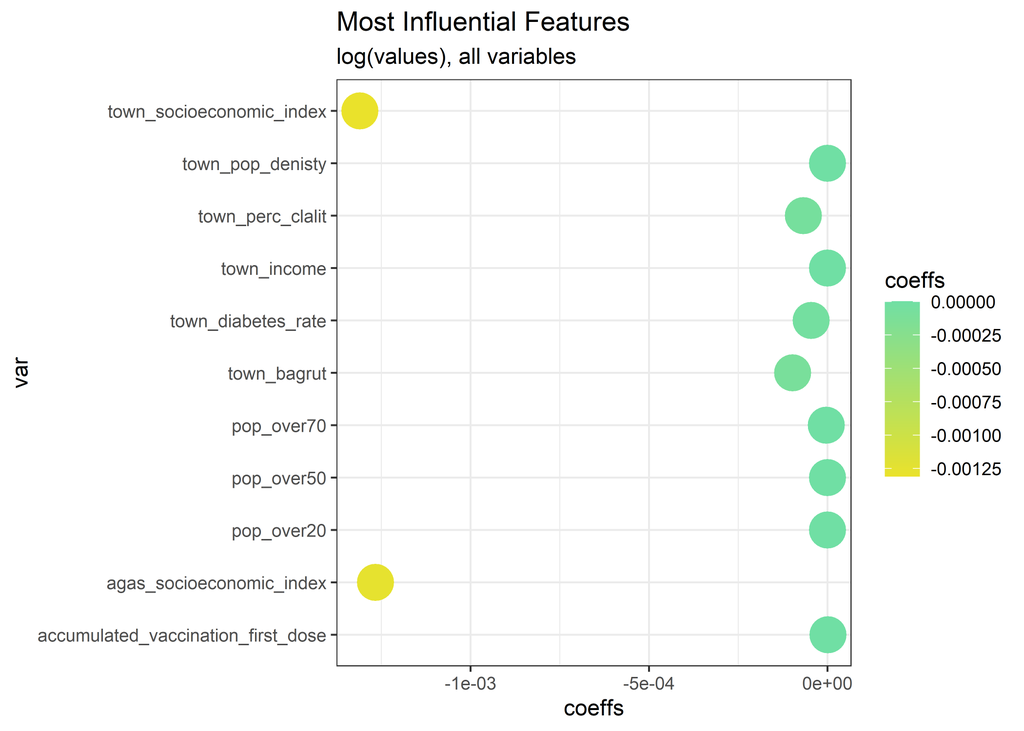

```r
features <- data.frame(coeffs=as.vector(coef(fit.cva, alpha=params1$a))[-c(1)], var=row.names(coef(fit.cva, alpha=params1$a))[-c(1)]) %>% arrange(desc(abs(coeffs)))

# Plot of the influence of the variables
theme_set(theme_bw())
ggplot(features, aes(x=coeffs, y=var, label=round(coeffs,2))) +
  geom_point(aes(color=coeffs),stat='identity', size=8)  +
  scale_color_gradientn(colors = colorRampPalette(c("#eae22b", "#70dfa4"))(10)) +
  labs(title="Most Influential Features",subtitle=str_c("log(values), all variables"))
```

```r
# Use the optimal parameters for choosing the optimal model and getting our forecast
forecasted <- predict(fit.cva, newdata=as.matrix(testers), alpha=a)
forecasted_train <- predict(fit.cva, newdata=as.matrix(trainers %>% dplyr::select(-y)), alpha=a)
save(forecasted, file="forecast.Rdata")

# The forecast of the Ridge model from Q2
forecasted_ridge <- as.matrix(testers)%*%as.vector(beta_optimal[,1])

# The RMSPEs
RMSPE <- sqrt(mean((forecasted-forecasted_ridge)^2))

RMSPE2 <- sqrt(sum((as.vector(trainers %>% dplyr::select(y))-forecasted_train)^2)/length(forecasted_train))

print(paste("Estimated RMSPE of validation dataset: ",round(RMSPE2,3)))
```

```
## [1] "Estimated RMSPE of validation dataset:  0.007"
```

```r
print(paste("Estimated RMSPE of test dataset: ",round(RMSPE,3)))
```

```
## [1] "Estimated RMSPE of test dataset:  0.004"
```